# SQL 4 Airline Data Analysis

```python
import sqlite3
import pandas as pd
import numpy as np
import matplotlib.pyplot as plt
%matplotlib inline
import seaborn as sns
import json
```

### One way to see data

```python
conn=sqlite3.connect('travel.sqlite')
cursor=conn.cursor()
```

```python
for row in cursor.execute("Select name from sqlite_master where type='table';"):
    print(list(row))
```

```
['aircrafts_data']
['airports_data']
['boarding_passes']
['bookings']
['flights']
['seats']
['ticket_flights']
['tickets']
```

#### Second way to see data

```python
%%capture
%load_ext sql
%sql sqlite:///travel.sqlite
```

```python
%%sql

SELECT *
  FROM sqlite_master
 WHERE type='table';
```

```
 * sqlite:///travel.sqlite
Done.
```

| type | name | tbl_name | rootpage | sql |
| --- | --- | --- | --- | --- |
| table | aircrafts_data | aircrafts_data | 2 | CREATE TABLE aircrafts_data ( aircraft_code character(3) NOT NULL, model jsonb NOT NULL, range integer NOT NULL, CONSTRAINT aircrafts_range_check CHECK ((range > 0)) ) |
| table | airports_data | airports_data | 3 | CREATE TABLE airports_data ( airport_code character(3) NOT NULL, airport_name jsonb NOT NULL, city jsonb NOT NULL, coordinates point NOT NULL, timezone text NOT NULL ) |
| table | boarding_passes | boarding_passes | 4 | CREATE TABLE boarding_passes ( ticket_no character(13) NOT NULL, flight_id integer NOT NULL, boarding_no integer NOT NULL, seat_no character varying(4) NOT NULL ) |
| table | bookings | bookings | 5 | CREATE TABLE bookings ( book_ref character(6) NOT NULL, book_date timestamp with time zone NOT NULL, total_amount numeric(10,2) NOT NULL ) |
| table | flights | flights | 6 | CREATE TABLE flights ( flight_id integer NOT NULL, flight_no character(6) NOT NULL, scheduled_departure timestamp with time zone NOT NULL, scheduled_arrival timestamp with time zone NOT NULL, departur… |
| table | seats | seats | 7 | CREATE TABLE seats ( aircraft_code character(3) NOT NULL, seat_no character varying(4) NOT NULL, fare_conditions character varying(10) NOT NULL ) |
| table | ticket_flights | ticket_flights | 8 | CREATE TABLE ticket_flights ( ticket_no character(13) NOT NULL, flight_id integer NOT NULL, fare_conditions character varying(10) NOT NULL, amount numeric(10,2) NOT NULL ) |
| table | tickets | tickets | 9 | CREATE TABLE tickets ( ticket_no character(13) NOT NULL, book_ref character(6) NOT NULL, passenger_id character varying(20) NOT NULL) |

```python
# Connect to the SQLite database
conn = sqlite3.connect('travel.sqlite')
cursor = conn.cursor()

# Get a list of table names
cursor.execute("SELECT name FROM sqlite_master WHERE type='table';")
table_names = cursor.fetchall()

# Loop through the table names and retrieve data
for table in table_names:
    table_name = table[0]

    print(f"Table: {table_name}")

    # Get column names
    cursor.execute(f"PRAGMA table_info({table_name});")
    columns = [column[1] for column in cursor.fetchall()]
    print("Columns:", columns)

    # Retrieve a few rows from the table
    cursor.execute(f"SELECT * FROM {table_name} LIMIT 3;")
    rows = cursor.fetchall()
    for row in rows:
        print(row)

    print("\n")
```

```
Table: aircrafts_data
Columns: ['aircraft_code', 'model', 'range']
('773', '{"en": "Boeing 777-300", "ru": "Боинг 777-300"}', 11100)
('763', '{"en": "Boeing 767-300", "ru": "Боинг 767-300"}', 7900)
('SU9', '{"en": "Sukhoi Superjet-100", "ru": "Сухой Суперджет-100"}', 3000)


Table: airports_data
Columns: ['airport_code', 'airport_name', 'city', 'coordinates', 'timezone']
('YKS', '{"en": "Yakutsk Airport", "ru": "Якутск"}', '{"en": "Yakutsk", "ru": "Якутск"}', '(129.77099609375,62.0932998657226562)', 'Asia/Yakutsk')
('MJZ', '{"en": "Mirny Airport", "ru": "Мирный"}', '{"en": "Mirnyj", "ru": "Мирный"}', '(114.03900146484375,62.534698486328125)', 'Asia/Yakutsk')
('KHV', '{"en": "Khabarovsk-Novy Airport", "ru": "Хабаровск-Новый"}', '{"en": "Khabarovsk", "ru": "Хабаровск"}', '(135.18800354004,48.5279998779300001)', 'Asia/Vladivostok')


Table: boarding_passes
Columns: ['ticket_no', 'flight_id', 'boarding_no', 'seat_no']
('0005435212351', 30625, 1, '2D')
('0005435212386', 30625, 2, '3G')
('0005435212381', 30625, 3, '4H')


Table: bookings
Columns: ['book_ref', 'book_date', 'total_amount']
('00000F', '2017-07-05 03:12:00+03', 265700)
('000012', '2017-07-14 09:02:00+03', 37900)
('000068', '2017-08-15 14:27:00+03', 18100)


Table: flights
Columns: ['flight_id', 'flight_no', 'scheduled_departure', 'scheduled_arrival', 'departure_airport', 'arrival_airport', 'status', 'aircraft_code', 'actual_departure', 'actual_arrival']
(1185, 'PG0134', '2017-09-10 09:50:00+03', '2017-09-10 14:55:00+03', 'DME', 'BTK', 'Scheduled', '319', '\\N', '\\N')
(3979, 'PG0052', '2017-08-25 14:50:00+03', '2017-08-25 17:35:00+03', 'VKO', 'HMA', 'Scheduled', 'CR2', '\\N', '\\N')
(4739, 'PG0561', '2017-09-05 12:30:00+03', '2017-09-05 14:15:00+03', 'VKO', 'AER', 'Scheduled', '763', '\\N', '\\N')


Table: seats
Columns: ['aircraft_code', 'seat_no', 'fare_conditions']
('319', '2A', 'Business')
('319', '2C', 'Business')
('319', '2D', 'Business')


Table: ticket_flights
Columns: ['ticket_no', 'flight_id', 'fare_conditions', 'amount']
('0005432159776', 30625, 'Business', 42100)
('0005435212351', 30625, 'Business', 42100)
('0005435212386', 30625, 'Business', 42100)


Table: tickets
Columns: ['ticket_no', 'book_ref', 'passenger_id']
('0005432000987', '06B046', '8149 604011')
('0005432000988', '06B046', '8499 420203')
('0005432000989', 'E170C3', '1011 752484')
```

```python
select aircraft_code,ticket_count,total_revenue,total_revenue/ticket_count as avg_revenue
from (select f.aircraft_code,count(ticket_no) as ticket_count,sum(amount) as total_revenue
      from ticket_flights t
      join flights f on t.flight_id=f.flight_id
      group by f.aircraft_code)
```

```
  Cell In[7], line 1
    select aircraft_code,ticket_count,total_revenue,total_revenue/ticket_count as avg_revenue
           ^
SyntaxError: invalid syntax
```

#### Observation

Seems like we have some data in multiple languages. We need to keep only understandable data

```python
aircrafts_data=pd.read_sql("""select *
                        From aircrafts_data;""" ,conn)
aircrafts_data
```

|  | aircraft_code | model | range |
| --- | --- | --- | --- |
| 0 | 773 | {"en": "Boeing 777-300", "ru": "Боинг 777-300"} | 11100 |
| 1 | 763 | {"en": "Boeing 767-300", "ru": "Боинг 767-300"} | 7900 |
| 2 | SU9 | {"en": "Sukhoi Superjet-100", "ru": "Сухой Суп... | 3000 |
| 3 | 320 | {"en": "Airbus A320-200", "ru": "Аэробус A320-... | 5700 |
| 4 | 321 | {"en": "Airbus A321-200", "ru": "Аэробус A321-... | 5600 |
| 5 | 319 | {"en": "Airbus A319-100", "ru": "Аэробус A319-... | 6700 |
| 6 | 733 | {"en": "Boeing 737-300", "ru": "Боинг 737-300"} | 4200 |
| 7 | CN1 | {"en": "Cessna 208 Caravan", "ru": "Сессна 208... | 1200 |
| 8 | CR2 | {"en": "Bombardier CRJ-200", "ru": "Бомбардье ... | 2700 |

#### Remove unnecessary data

```python
aircrafts_data['model']=aircrafts_data['model'].apply(lambda x: json.loads(x)['en'])
aircrafts_data
```

|  | aircraft_code | model | range |
| --- | --- | --- | --- |
| 0 | 773 | Boeing 777-300 | 11100 |
| 1 | 763 | Boeing 767-300 | 7900 |
| 2 | SU9 | Sukhoi Superjet-100 | 3000 |
| 3 | 320 | Airbus A320-200 | 5700 |
| 4 | 321 | Airbus A321-200 | 5600 |
| 5 | 319 | Airbus A319-100 | 6700 |
| 6 | 733 | Boeing 737-300 | 4200 |
| 7 | CN1 | Cessna 208 Caravan | 1200 |
| 8 | CR2 | Bombardier CRJ-200 | 2700 |

```python
aircrafts_data=pd.read_sql("""select *
                        From aircrafts_data;""" ,conn)
aircrafts_data['model']=aircrafts_data['model'].apply(lambda x: json.loads(x)['en'])
aircrafts_data
```

|  | aircraft_code | model | range |
| --- | --- | --- | --- |
| 0 | 773 | Boeing 777-300 | 11100 |
| 1 | 763 | Boeing 767-300 | 7900 |
| 2 | SU9 | Sukhoi Superjet-100 | 3000 |
| 3 | 320 | Airbus A320-200 | 5700 |
| 4 | 321 | Airbus A321-200 | 5600 |
| 5 | 319 | Airbus A319-100 | 6700 |
| 6 | 733 | Boeing 737-300 | 4200 |
| 7 | CN1 | Cessna 208 Caravan | 1200 |
| 8 | CR2 | Bombardier CRJ-200 | 2700 |

```python
airports_data=pd.read_sql("""select *
                        From airports_data;""" ,conn)
airports_data
```

|  | airport_code | airport_name | city | coordinates | timezone |
| --- | --- | --- | --- | --- | --- |
| 0 | YKS | {"en": "Yakutsk Airport", "ru": "Якутск"} | {"en": "Yakutsk", "ru": "Якутск"} | (129.77099609375,62.0932998657226562) | Asia/Yakutsk |
| 1 | MJZ | {"en": "Mirny Airport", "ru": "Мирный"} | {"en": "Mirnyj", "ru": "Мирный"} | (114.03900146484375,62.534698486328125) | Asia/Yakutsk |
| 2 | KHV | {"en": "Khabarovsk-Novy Airport", "ru": "Хабар... | {"en": "Khabarovsk", "ru": "Хабаровск"} | (135.18800354004,48.5279998779300001) | Asia/Vladivostok |
| 3 | PKC | {"en": "Yelizovo Airport", "ru": "Елизово"} | {"en": "Petropavlovsk", "ru": "Петропавловск-К... | (158.453994750976562,53.1679000854492188) | Asia/Kamchatka |
| 4 | UUS | {"en": "Yuzhno-Sakhalinsk Airport", "ru": "Хом... | {"en": "Yuzhno-Sakhalinsk", "ru": "Южно-Сахали... | (142.718002319335938,46.8886985778808594) | Asia/Sakhalin |
| ... | ... | ... | ... | ... | ... |
| 99 | MMK | {"en": "Murmansk Airport", "ru": "Мурманск"} | {"en": "Murmansk", "ru": "Мурманск"} | (32.7508010864257812,68.7817001342773438) | Europe/Moscow |
| 100 | ABA | {"en": "Abakan Airport", "ru": "Абакан"} | {"en": "Abakan", "ru": "Абакан"} | (91.3850021362304688,53.7400016784667969) | Asia/Krasnoyarsk |
| 101 | BAX | {"en": "Barnaul Airport", "ru": "Барнаул"} | {"en": "Barnaul", "ru": "Барнаул"} | (83.5384979248046875,53.363800048828125) | Asia/Krasnoyarsk |
| 102 | AAQ | {"en": "Anapa Vityazevo Airport", "ru": "Витяз... | {"en": "Anapa", "ru": "Анапа"} | (37.3473014831539984,45.002101898192997) | Europe/Moscow |
| 103 | CNN | {"en": "Chulman Airport", "ru": "Чульман"} | {"en": "Neryungri", "ru": "Нерюнгри"} | (124.914001464839998,56.9138984680179973) | Asia/Yakutsk |

104 rows × 5 columns

```python
airports_data['airport_name']=airports_data['airport_name'].apply(lambda x: json.loads(x)['en'])
airports_data['city']=airports_data['city'].apply(lambda x: json.loads(x)['en'])
airports_data
```

|  | airport_code | airport_name | city | coordinates | timezone |
| --- | --- | --- | --- | --- | --- |
| 0 | YKS | Yakutsk Airport | Yakutsk | (129.77099609375,62.0932998657226562) | Asia/Yakutsk |
| 1 | MJZ | Mirny Airport | Mirnyj | (114.03900146484375,62.534698486328125) | Asia/Yakutsk |
| 2 | KHV | Khabarovsk-Novy Airport | Khabarovsk | (135.18800354004,48.5279998779300001) | Asia/Vladivostok |
| 3 | PKC | Yelizovo Airport | Petropavlovsk | (158.453994750976562,53.1679000854492188) | Asia/Kamchatka |
| 4 | UUS | Yuzhno-Sakhalinsk Airport | Yuzhno-Sakhalinsk | (142.718002319335938,46.8886985778808594) | Asia/Sakhalin |
| ... | ... | ... | ... | ... | ... |
| 99 | MMK | Murmansk Airport | Murmansk | (32.7508010864257812,68.7817001342773438) | Europe/Moscow |
| 100 | ABA | Abakan Airport | Abakan | (91.3850021362304688,53.7400016784667969) | Asia/Krasnoyarsk |
| 101 | BAX | Barnaul Airport | Barnaul | (83.5384979248046875,53.363800048828125) | Asia/Krasnoyarsk |
| 102 | AAQ | Anapa Vityazevo Airport | Anapa | (37.3473014831539984,45.002101898192997) | Europe/Moscow |
| 103 | CNN | Chulman Airport | Neryungri | (124.914001464839998,56.9138984680179973) | Asia/Yakutsk |

104 rows × 5 columns

```python
boarding_passes = pd.read_sql_query("select * from boarding_passes", conn)
boarding_passes
```

|  | ticket_no | flight_id | boarding_no | seat_no |
| --- | --- | --- | --- | --- |
| 0 | 0005435212351 | 30625 | 1 | 2D |
| 1 | 0005435212386 | 30625 | 2 | 3G |
| 2 | 0005435212381 | 30625 | 3 | 4H |
| 3 | 0005432211370 | 30625 | 4 | 5D |
| 4 | 0005435212357 | 30625 | 5 | 11A |
| ... | ... | ... | ... | ... |
| 579681 | 0005434302871 | 19945 | 85 | 20F |
| 579682 | 0005432892791 | 19945 | 86 | 21C |
| 579683 | 0005434302869 | 19945 | 87 | 20E |
| 579684 | 0005432802476 | 19945 | 88 | 21F |
| 579685 | 0005432802482 | 19945 | 89 | 21E |

579686 rows × 4 columns

```python
bookings = pd.read_sql_query("select * from bookings", conn)
bookings
```

|  | book_ref | book_date | total_amount |
| --- | --- | --- | --- |
| 0 | 00000F | 2017-07-05 03:12:00+03 | 265700 |
| 1 | 000012 | 2017-07-14 09:02:00+03 | 37900 |
| 2 | 000068 | 2017-08-15 14:27:00+03 | 18100 |
| 3 | 000181 | 2017-08-10 13:28:00+03 | 131800 |
| 4 | 0002D8 | 2017-08-07 21:40:00+03 | 23600 |
| ... | ... | ... | ... |
| 262783 | FFFEF3 | 2017-07-17 07:23:00+03 | 56000 |
| 262784 | FFFF2C | 2017-08-08 05:55:00+03 | 10800 |
| 262785 | FFFF43 | 2017-07-20 20:42:00+03 | 78500 |
| 262786 | FFFFA8 | 2017-08-08 04:45:00+03 | 28800 |
| 262787 | FFFFF7 | 2017-07-01 22:12:00+03 | 73600 |

262788 rows × 3 columns

```python
flights = pd.read_sql_query("select * from flights", conn)
flights
```

|  | flight_id | flight_no | scheduled_departure | scheduled_arrival | departure_airport | arrival_airport | status | aircraft_code | actual_departure | actual_arrival |
| --- | --- | --- | --- | --- | --- | --- | --- | --- | --- | --- |
| 0 | 1185 | PG0134 | 2017-09-10 09:50:00+03 | 2017-09-10 14:55:00+03 | DME | BTK | Scheduled | 319 | \N | \N |
| 1 | 3979 | PG0052 | 2017-08-25 14:50:00+03 | 2017-08-25 17:35:00+03 | VKO | HMA | Scheduled | CR2 | \N | \N |
| 2 | 4739 | PG0561 | 2017-09-05 12:30:00+03 | 2017-09-05 14:15:00+03 | VKO | AER | Scheduled | 763 | \N | \N |
| 3 | 5502 | PG0529 | 2017-09-12 09:50:00+03 | 2017-09-12 11:20:00+03 | SVO | UFA | Scheduled | 763 | \N | \N |
| 4 | 6938 | PG0461 | 2017-09-04 12:25:00+03 | 2017-09-04 13:20:00+03 | SVO | ULV | Scheduled | SU9 | \N | \N |
| ... | ... | ... | ... | ... | ... | ... | ... | ... | ... | ... |
| 33116 | 33117 | PG0063 | 2017-08-02 19:25:00+03 | 2017-08-02 20:10:00+03 | SKX | SVO | Arrived | CR2 | 2017-08-02 19:25:00+03 | 2017-08-02 20:10:00+03 |
| 33117 | 33118 | PG0063 | 2017-07-28 19:25:00+03 | 2017-07-28 20:10:00+03 | SKX | SVO | Arrived | CR2 | 2017-07-28 19:30:00+03 | 2017-07-28 20:15:00+03 |
| 33118 | 33119 | PG0063 | 2017-09-08 19:25:00+03 | 2017-09-08 20:10:00+03 | SKX | SVO | Scheduled | CR2 | \N | \N |
| 33119 | 33120 | PG0063 | 2017-08-01 19:25:00+03 | 2017-08-01 20:10:00+03 | SKX | SVO | Arrived | CR2 | 2017-08-01 19:26:00+03 | 2017-08-01 20:12:00+03 |
| 33120 | 33121 | PG0063 | 2017-08-26 19:25:00+03 | 2017-08-26 20:10:00+03 | SKX | SVO | Scheduled | CR2 | \N | \N |

33121 rows × 10 columns

```python
seats = pd.read_sql_query("select * from seats", conn)
seats
```

|  | aircraft_code | seat_no | fare_conditions |
| --- | --- | --- | --- |
| 0 | 319 | 2A | Business |
| 1 | 319 | 2C | Business |
| 2 | 319 | 2D | Business |
| 3 | 319 | 2F | Business |
| 4 | 319 | 3A | Business |
| ... | ... | ... | ... |
| 1334 | 773 | 48H | Economy |
| 1335 | 773 | 48K | Economy |
| 1336 | 773 | 49A | Economy |
| 1337 | 773 | 49C | Economy |
| 1338 | 773 | 49D | Economy |

1339 rows × 3 columns

```python
ticket_flights = pd.read_sql_query("select * from ticket_flights", conn)
ticket_flights
```

|  | ticket_no | flight_id | fare_conditions | amount |
| --- | --- | --- | --- | --- |
| 0 | 0005432159776 | 30625 | Business | 42100 |
| 1 | 0005435212351 | 30625 | Business | 42100 |
| 2 | 0005435212386 | 30625 | Business | 42100 |
| 3 | 0005435212381 | 30625 | Business | 42100 |
| 4 | 0005432211370 | 30625 | Business | 42100 |
| ... | ... | ... | ... | ... |
| 1045721 | 0005435097522 | 32094 | Economy | 5200 |
| 1045722 | 0005435097521 | 32094 | Economy | 5200 |
| 1045723 | 0005435104384 | 32094 | Economy | 5200 |
| 1045724 | 0005435104352 | 32094 | Economy | 5200 |
| 1045725 | 0005435104389 | 32094 | Economy | 5200 |

1045726 rows × 4 columns

```python
tickets = pd.read_sql_query("select * from tickets", conn)
tickets
```

|  | ticket_no | book_ref | passenger_id |
| --- | --- | --- | --- |
| 0 | 0005432000987 | 06B046 | 8149 604011 |
| 1 | 0005432000988 | 06B046 | 8499 420203 |
| 2 | 0005432000989 | E170C3 | 1011 752484 |
| 3 | 0005432000990 | E170C3 | 4849 400049 |
| 4 | 0005432000991 | F313DD | 6615 976589 |
| ... | ... | ... | ... |
| 366728 | 0005435999869 | D730BA | 0474 690760 |
| 366729 | 0005435999870 | D730BA | 6535 751108 |
| 366730 | 0005435999871 | A1AD46 | 1596 156448 |
| 366731 | 0005435999872 | 7B6A53 | 9374 822707 |
| 366732 | 0005435999873 | 7B6A53 | 7380 075822 |

366733 rows × 3 columns

## AirPlane Models with their range

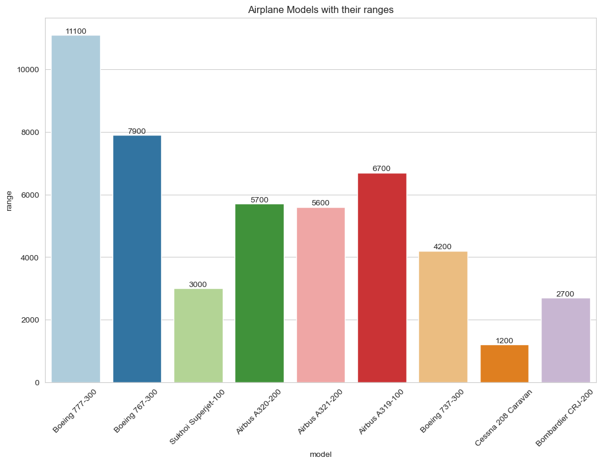

```python
# Plt formats
sns.set_style('whitegrid')
fig,axes=plt.subplots(figsize=(12,8))

ax=sns.barplot(x='model',y='range',data=aircrafts_data,palette='Paired')

#For data label
for container in ax.containers:
    ax.bar_label(container)

plt.title('Airplane Models with their ranges')
plt.xticks(rotation=45)
plt.show()
```

## Planes have more than 100 seats

```python
import pandas as pd

# SQL query to extract 'en' from the 'model' column in the database
sql_query = """
    SELECT CAST(JSON_EXTRACT(model, '$.en') AS CHAR) AS model_en, COUNT(s.seat_no) AS seat_count
    FROM seats s
    JOIN aircrafts_data a ON a.aircraft_code = s.aircraft_code
    GROUP BY model_en
    HAVING seat_count > 100
    order by seat_count desc
"""

# Execute the SQL query and read the result into a DataFrame
df = pd.read_sql(sql_query, conn)

# Display the resulting DataFrame with seat counts
print(df)
```

```
          model_en  seat_count
0   Boeing 777-300         402
1   Boeing 767-300         222
2  Airbus A321-200         170
3  Airbus A320-200         140
4   Boeing 737-300         130
5  Airbus A319-100         116
```

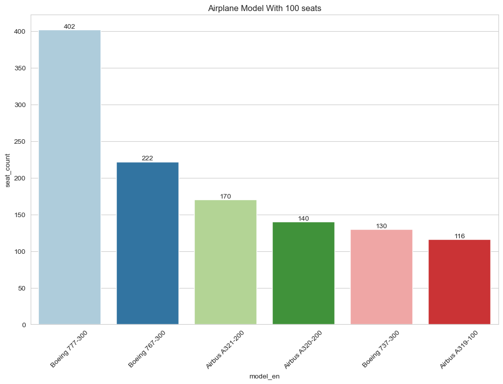

```python
# Plt formats
sns.set_style('whitegrid')
fig,axes=plt.subplots(figsize=(12,8))

ax=sns.barplot(x='model_en',y='seat_count',data=df,palette='Paired')

#For data label
for container in ax.containers:
    ax.bar_label(container)

plt.title('Airplane Model With 100 seats')
plt.xticks(rotation=45)
plt.show()
```

#### Observation

Here we successfully derived the names of airplanes using their codes So it seems like " Boeing 777-300 " is having maximum number of seats (402).

## Number of tickets booked and total amount earned changed with the time

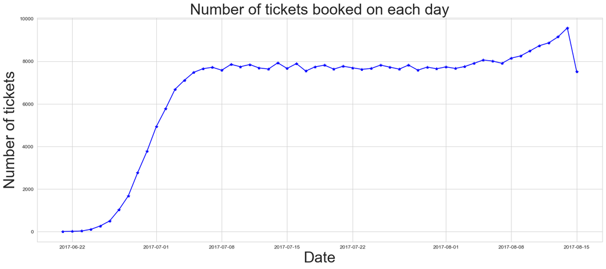

```python
tickets=pd.read_sql("""select *
                        from tickets t
                        join bookings b
                         on t.book_ref=b.book_ref""",conn)
tickets['book_date']=pd.to_datetime(tickets['book_date'])
tickets['date']=tickets['book_date'].dt.date
tickets_count = tickets.groupby('date')[['date']].count()


#Plotting
%matplotlib inline
plt.figure(figsize=(20,8))
plt.plot(tickets_count.index,tickets_count['date'],color='blue',scalex=True,marker="*")
plt.title('Number of tickets booked on each day',fontsize=30)
plt.xlabel('Date',fontsize=30)
plt.ylabel('Number of tickets',fontsize=30)
plt.show()
```

#### Observation

1. Utilized a line chart visualization to analyze the trend of ticket bookings and revenue earned.
2. The number of tickets booked showed a gradual increase from June 22nd to July 7th.
3. From July 8th until August, ticket bookings remained relatively stable with a noticeable peak in bookings on a single day.
4. The revenue earned by the company is closely correlated with the number of tickets booked.
5. The total revenue earned followed a similar trend throughout the analyzed time period.
6. Further exploration of the factors contributing to the peak in ticket bookings could help increase overall revenue and optimize operational strategies.

[figure not shown]

```python
booking=pd.read_sql("""select *
                        from bookings
                        """,conn)
booking['book_date']=pd.to_datetime(tickets['book_date'])
booking['date']=tickets['book_date'].dt.date
booking_amount = booking.groupby('date')[['total_amount']].sum()


#Plotting
plt.figure(figsize=(20,8))
plt.plot(booking_amount.index,booking_amount['total_amount'],color='blue',scalex=True,marker="*")
plt.title('Number of tickets booked on each day',fontsize=30)
plt.xlabel('Date',fontsize=30)
plt.ylabel('Total amount earned',fontsize=30)
plt.show()
```

### Fare Distribution of flights

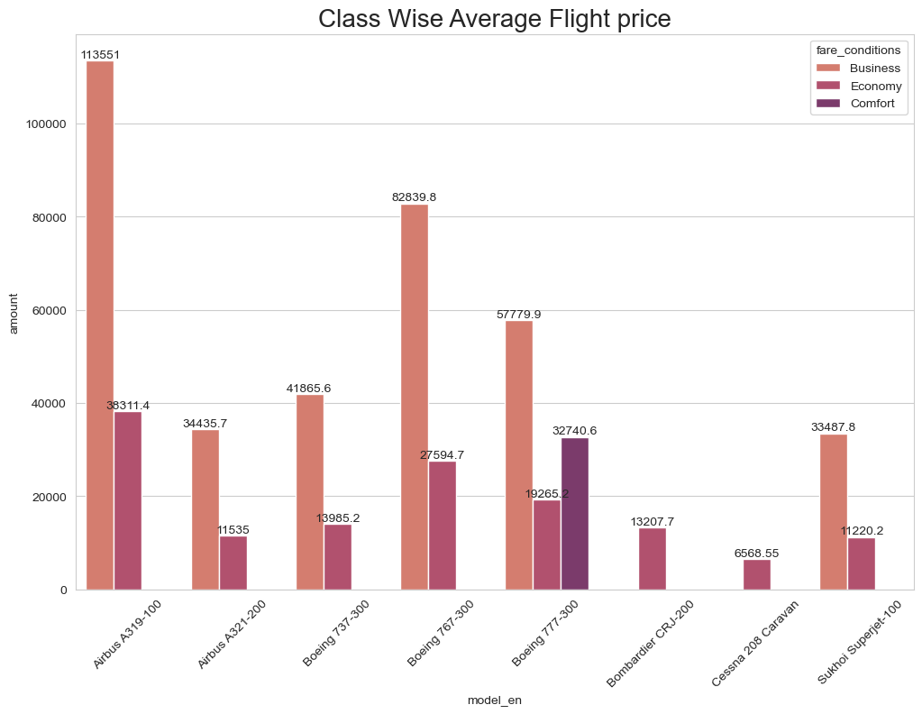

```python
df=pd.read_sql("""select CAST(JSON_EXTRACT(model, '$.en') AS CHAR) AS model_en,fare_conditions,avg(t.amount) as amount
                    from ticket_flights t
                    join flights f on t.flight_id=f.flight_id
                    join aircrafts_data a on a.aircraft_code=f.aircraft_code
                    group by a.model,fare_conditions """,conn)
df

sns.set_style('whitegrid')
fig,axes=plt.subplots(figsize=(12,8))
ax=sns.barplot(x='model_en',y='amount',hue='fare_conditions',data=df,palette='flare')
for container in ax.containers:
    ax.bar_label(container)
plt.title('Class Wise Average Flight price',fontsize=20)
plt.xticks(rotation=45)
plt.show()
```

# Analyzing occupancy rate

```python
revenue=pd.read_sql("""select aircraft_code,ticket_count,total_revenue,total_revenue/ticket_count as avg_revenue
                        from (select f.aircraft_code,count(ticket_no) as ticket_count,sum(amount) as total_revenue
                              from ticket_flights t
                              join flights f on t.flight_id=f.flight_id
                              group by f.aircraft_code)""",conn)
revenue.to_csv('revenue.csv')
```

```python
revenue
```

|  | aircraft_code | ticket_count | total_revenue | avg_revenue |
| --- | --- | --- | --- | --- |
| 0 | 319 | 52853 | 2706163100 | 51201 |
| 1 | 321 | 107129 | 1638164100 | 15291 |
| 2 | 733 | 86102 | 1426552100 | 16568 |
| 3 | 763 | 124774 | 4371277100 | 35033 |
| 4 | 773 | 144376 | 3431205500 | 23765 |
| 5 | CN1 | 14672 | 96373800 | 6568 |
| 6 | CR2 | 150122 | 1982760500 | 13207 |
| 7 | SU9 | 365698 | 5114484700 | 13985 |

## Calculate the average occupancy rate

```python
occupancy_rate = pd.read_sql_query("""select a.aircraft_code,avg(a.seats_count) as booked_seats, b.num_seats, avg(a.seats_count)/b.num_seats as occupancy_rate from
                (select aircraft_code,flights.flight_id,count(*) as seats_count from boarding_passes
                    inner join flights
                    on boarding_passes.flight_id = flights.flight_id
                    group by aircraft_code,flights.flight_id) as a
                    inner join
                    (select aircraft_code,count(*) as num_seats from seats
                    group by aircraft_code) as b
                    on a.aircraft_code = b.aircraft_code group by a.aircraft_code""", conn
                  )
occupancy_rate
```

|  | aircraft_code | booked_seats | num_seats | occupancy_rate |
| --- | --- | --- | --- | --- |
| 0 | 319 | 53.583181 | 116 | 0.461924 |
| 1 | 321 | 88.809231 | 170 | 0.522407 |
| 2 | 733 | 80.255462 | 130 | 0.617350 |
| 3 | 763 | 113.937294 | 222 | 0.513231 |
| 4 | 773 | 264.925806 | 402 | 0.659019 |
| 5 | CN1 | 6.004431 | 12 | 0.500369 |
| 6 | CR2 | 21.482847 | 50 | 0.429657 |
| 7 | SU9 | 56.812113 | 97 | 0.585692 |

#### Calculating how much the total annual turnover would increase by giving all aircraft a 10% higher occupancy rate

```python
occupancy_rate['inc occupancy rate'] = occupancy_rate['occupancy_rate']+occupancy_rate['occupancy_rate']*0.1
occupancy_rate
```

|  | aircraft_code | booked_seats | num_seats | occupancy_rate | inc occupancy rate |
| --- | --- | --- | --- | --- | --- |
| 0 | 319 | 53.583181 | 116 | 0.461924 | 0.508116 |
| 1 | 321 | 88.809231 | 170 | 0.522407 | 0.574648 |
| 2 | 733 | 80.255462 | 130 | 0.617350 | 0.679085 |
| 3 | 763 | 113.937294 | 222 | 0.513231 | 0.564554 |
| 4 | 773 | 264.925806 | 402 | 0.659019 | 0.724921 |
| 5 | CN1 | 6.004431 | 12 | 0.500369 | 0.550406 |
| 6 | CR2 | 21.482847 | 50 | 0.429657 | 0.472623 |
| 7 | SU9 | 56.812113 | 97 | 0.585692 | 0.644261 |

```python
pd.set_option("display.float_format",str)
total_revenue = pd.read_sql_query("""select aircraft_code,sum(amount) as total_revenue from ticket_flights
                        join flights on ticket_flights.flight_id = flights.flight_id
                        group by aircraft_code""", conn)
total_revenue

occupancy_rate['inc Total Annual Turnover'] = (total_revenue['total_revenue']/occupancy_rate['occupancy_rate'])*occupancy_rate['inc occupancy rate']
occupancy_rate
```

|  | aircraft_code | booked_seats | num_seats | occupancy_rate | inc occupancy rate | inc Total Annual Turnover |
| --- | --- | --- | --- | --- | --- | --- |
| 0 | 319 | 53.58318098720292 | 116 | 0.46192397402761143 | 0.5081163714303726 | 2976779410.0 |
| 1 | 321 | 88.80923076923077 | 170 | 0.5224072398190045 | 0.574647963800905 | 1801980510.0 |
| 2 | 733 | 80.25546218487395 | 130 | 0.617349709114415 | 0.6790846800258565 | 1569207310.0000002 |
| 3 | 763 | 113.93729372937294 | 222 | 0.5132310528350132 | 0.5645541581185146 | 4808404810.0 |
| 4 | 773 | 264.9258064516129 | 402 | 0.659019419033863 | 0.7249213609372492 | 3774326050.0 |
| 5 | CN1 | 6.004431314623338 | 12 | 0.5003692762186115 | 0.5504062038404727 | 106011180.00000001 |
| 6 | CR2 | 21.48284690220174 | 50 | 0.42965693804403476 | 0.4726226318484382 | 2181036550.0 |
| 7 | SU9 | 56.81211267605634 | 97 | 0.5856918832583128 | 0.644261071584144 | 5625933169.999999 |

## Conclusion

In conclusion, airlines can maximize profitability by analyzing revenue data and making informed decisions. Factors such as total revenue, average revenue per ticket, and average occupancy per aircraft play a crucial role in this analysis. By identifying areas for improvement, adjusting pricing strategies, and optimizing routes, airlines can increase their profitability. However, it's important for airlines to consider consumer happiness and safety while striving for profit. Balancing these factors is key to long-term success in the competitive airline industry. Adopting a data-driven approach to revenue analysis and optimization can lead to sustainable growth and success.